# 1- Data Tidying:

## **Part I**

### **Tuberculosis Dataset**

This dataset outlines the number of tuberculosis patients in different countries in the year 2000.  
Dataset name: tb-raw.csv  
A few notes on the raw data set:

- The columns starting with "m" or "f" contain multiple variables:
  - Sex ("m" or "f")
  - Age Group ("0-14","15-24", "25-34", "45-54", "55-64", "65", "unknown")
- Mixture of 0s and missing values("NaN"). This is due to the data collection process and the distinction is important for this dataset.

#### Task: Apply Data Tidying techniques to get a tidier dataset with more representive columns, please do it step-by-step and explain each step you are doing.

### 1. Dataset Loaded

```python
import pandas as pd

data = pd.read_csv('tb-raw.csv')
```

### 2. Data expansion by melting it. - id_varse --> Columns that's data is unchanged - creating new columns - age_sex and counting its values.

```python
data = data.melt(id_vars=['country', 'year'], var_name='age_sex', value_name='count')
```

### 3. Analysing the pattern here and extracting data accordingly - Creating sex and age_group column - extracting the pattern - m/f for if its male or female. 2 to 4 digit number for the age group.

```python
# Step 3: Extract relevant information
data[['sex', 'age_group']] = data['age_sex'].str.extract(r'([mf])(\d{2,4})')
```

### 4. Filling missing values

```python
data['count'] = data['count'].fillna(0)
```

### 5. Organizing columns

```python
tidy_data = data[['country', 'year', 'sex', 'age_group', 'count']]
```

### 6. Converting data to csv file.

```python
tidy_data.to_csv('tidied_dataset.csv', index=False)
```

## **Part II**

Observe the following dataset: ./CSVs/salesMinimized.csv Please observe columns thoroughly as you need to apply some common-sense to represent the columns correctly.

#### Task: Apply Data Tidying techniques to get a tidier dataset with more representive columns, please do it step-by-step and explain each step you are doing.

```python
df = pd.read_csv('salesMinimized.csv')
```

```python
df.dropna(axis=1, how="all",inplace=True)
df.fillna(-1, inplace=True)
print(df.head())
```

```
   Unnamed: 0                             id        item_id    dept_id
0           0  HOBBIES_1_001_CA_1_validation  HOBBIES_1_001  HOBBIES_1  \
1           1  HOBBIES_1_002_CA_1_validation  HOBBIES_1_002  HOBBIES_1
2           2  HOBBIES_1_003_CA_1_validation  HOBBIES_1_003  HOBBIES_1
3           3  HOBBIES_1_004_CA_1_validation  HOBBIES_1_004  HOBBIES_1
4           4  HOBBIES_1_005_CA_1_validation  HOBBIES_1_005  HOBBIES_1

    cat_id store_id state_id  d_1  d_2  d_3  ...  d_61  d_62  d_63  d_64
0  HOBBIES     CA_1       CA    0    0    0  ...     0     0     0     0  \
1  HOBBIES     CA_1       CA    0    0    0  ...     0     0     0     0
2  HOBBIES     CA_1       CA    0    0    0  ...     0     0     0     0
3  HOBBIES     CA_1       CA    0    0    0  ...     1     0     0     0
4  HOBBIES     CA_1       CA    0    0    0  ...     0     0     0     0

   d_65  d_66  d_67  d_68  d_69  d_70
0     0     0     0     0     0     0
1     0     0     0     0     0     0
2     0     0     0     0     0     0
3     0     0     1     0     0     1
4     0     0     0     0     0     0

[5 rows x 77 columns]
```

### Renaming to organize

```python
df.rename(columns={
    'id': 'Sales_ID',
    'item_id': 'Item_ID',
    'dept_id': 'Department_ID',
    'cat_id': 'Category_ID',
    'store_id': 'Store_ID',
    'state_id': 'State_ID',
    # Add more renames as necessary
}, inplace=True)

df.to_csv('clean_salesMinimized.csv', index=False)
```

## PART III

Using Boston House pricing dataset, apply outlier detection techniques discussed in class to detect outliers. Use different techniques and comment your code.  
You need to check how to load the dataset correctly!

1. You should include some Visualization techniques
2. You should include some statistical approaches
3. You should analyze your attributes using Univariant and multivariant outlier detection techniques.
4. Choose one or more of your outlier detection techniques and remove outliers

```python
# Importing
data_url = "http://lib.stat.cmu.edu/datasets/boston"
```

### Converting boston dataset to CSV - Reading the file and naming the columns - Converting data to 1D - Removing NaN values - Converting data to 2D

```python
import pandas as pd
import numpy as np

df = pd.read_csv(
    filepath_or_buffer="http://lib.stat.cmu.edu/datasets/boston",
    delim_whitespace=True,
    skiprows=21,
    header=None,
)

columns = [
    'CRIM',
    'ZN',
    'INDUS',
    'CHAS',
    'NOX',
    'RM',
    'AGE',
    'DIS',
    'RAD',
    'TAX',
    'PTRATIO',
    'B',
    'LSTAT',
    'MEDV',
]


numm_value = df.values.flatten()
all_values = numm_value[~np.isnan(numm_value)]

#Reshape the values to have 14 columns and make a new df out of them
df = pd.DataFrame(
    data = all_values.reshape(-1, len(columns)),
    columns = columns,
)

df.to_csv('boston.csv', index=False)
```

# Using histogram to Visualize

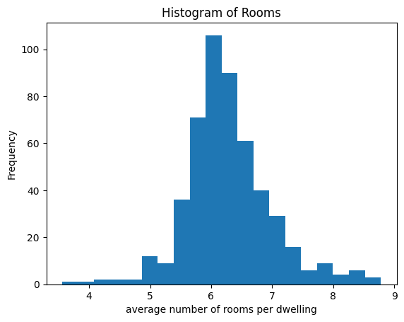

```python
import matplotlib.pyplot as plt

plt.hist(df['RM'], bins=20)
plt.xlabel('average number of rooms per dwelling')
plt.ylabel('Frequency')
plt.title('Histogram of Rooms')
plt.show()
```

# Statistical Approach

```python
import pandas as pd
import numpy as np

# Calculate basic statistics
basic_stats = df.describe()

# Calculate correlation coefficients
correlation_matrix = df.corr()

# Print the results
print("Basic Statistics:")
print(basic_stats)

print("\n Correlation Coefficients:")
print(correlation_matrix)
```

```
Basic Statistics:
             CRIM          ZN       INDUS        CHAS         NOX          RM
count  506.000000  506.000000  506.000000  506.000000  506.000000  506.000000  \
mean     3.613524   11.363636   11.136779    0.069170    0.554695    6.284634
std      8.601545   23.322453    6.860353    0.253994    0.115878    0.702617
min      0.006320    0.000000    0.460000    0.000000    0.385000    3.561000
25%      0.082045    0.000000    5.190000    0.000000    0.449000    5.885500
50%      0.256510    0.000000    9.690000    0.000000    0.538000    6.208500
75%      3.677083   12.500000   18.100000    0.000000    0.624000    6.623500
max     88.976200  100.000000   27.740000    1.000000    0.871000    8.780000

              AGE         DIS         RAD         TAX     PTRATIO           B
count  506.000000  506.000000  506.000000  506.000000  506.000000  506.000000  \
mean    68.574901    3.795043    9.549407  408.237154   18.455534  356.674032
std     28.148861    2.105710    8.707259  168.537116    2.164946   91.294864
min      2.900000    1.129600    1.000000  187.000000   12.600000    0.320000
25%     45.025000    2.100175    4.000000  279.000000   17.400000  375.377500
50%     77.500000    3.207450    5.000000  330.000000   19.050000  391.440000
75%     94.075000    5.188425   24.000000  666.000000   20.200000  396.225000
max    100.000000   12.126500   24.000000  711.000000   22.000000  396.900000

            LSTAT        MEDV
count  506.000000  506.000000
mean    12.653063   22.532806
std      7.141062    9.197104
min      1.730000    5.000000
25%      6.950000   17.025000
50%     11.360000   21.200000
75%     16.955000   25.000000
max     37.970000   50.000000

 Correlation Coefficients:
             CRIM        ZN     INDUS      CHAS       NOX        RM       AGE
CRIM     1.000000 -0.200469  0.406583 -0.055892  0.420972 -0.219247  0.352734  \
ZN      -0.200469  1.000000 -0.533828 -0.042697 -0.516604  0.311991 -0.569537
INDUS    0.406583 -0.533828  1.000000  0.062938  0.763651 -0.391676  0.644779
CHAS    -0.055892 -0.042697  0.062938  1.000000  0.091203  0.091251  0.086518
NOX      0.420972 -0.516604  0.763651  0.091203  1.000000 -0.302188  0.731470
RM      -0.219247  0.311991 -0.391676  0.091251 -0.302188  1.000000 -0.240265
AGE      0.352734 -0.569537  0.644779  0.086518  0.731470 -0.240265  1.000000
```

[output cut: 8 more lines]

```
              DIS       RAD       TAX   PTRATIO         B     LSTAT      MEDV
CRIM    -0.379670  0.625505  0.582764  0.289946 -0.385064  0.455621 -0.388305
ZN       0.664408 -0.311948 -0.314563 -0.391679  0.175520 -0.412995  0.360445
INDUS   -0.708027  0.595129  0.720760  0.383248 -0.356977  0.603800 -0.483725
CHAS    -0.099176 -0.007368 -0.035587 -0.121515  0.048788 -0.053929  0.175260
NOX     -0.769230  0.611441  0.668023  0.188933 -0.380051  0.590879 -0.427321
RM       0.205246 -0.209847 -0.292048 -0.355501  0.128069 -0.613808  0.695360
AGE     -0.747881  0.456022  0.506456  0.261515 -0.273534  0.602339 -0.376955
DIS      1.000000 -0.494588 -0.534432 -0.232471  0.291512 -0.496996  0.249929
RAD     -0.494588  1.000000  0.910228  0.464741 -0.444413  0.488676 -0.381626
TAX     -0.534432  0.910228  1.000000  0.460853 -0.441808  0.543993 -0.468536
PTRATIO -0.232471  0.464741  0.460853  1.000000 -0.177383  0.374044 -0.507787
B        0.291512 -0.444413 -0.441808 -0.177383  1.000000 -0.366087  0.333461
LSTAT   -0.496996  0.488676  0.543993  0.374044 -0.366087  1.000000 -0.737663
MEDV     0.249929 -0.381626 -0.468536 -0.507787  0.333461 -0.737663  1.000000
```

# Calculating z score and removing outliers

```python
from scipy import stats

# Calculate z-scores
z_scores = stats.zscore(df)


# Find all data points with a z-score greater than 3 or less than -3
outliers = (z_scores > 3).any(axis=1) | (z_scores < -3).any(axis=1)


print("z score approach outliers: ",sum(outliers))


Q1 = df.quantile(0.25)
Q3 = df.quantile(0.75)
IQR = Q3 - Q1


outliers = ((df < (Q1 - 1.5 * IQR)) | (df > (Q3 + 1.5 * IQR))).any(axis=1)

# Print the number of outliers
print("whsiker approach outlier ->: ",sum(outliers))


#Remove outliers
df = df[~outliers]
```

```
z score approach outliers:  91
whsiker approach outlier ->:  238
```